# An introduction to `FGLMtrunc`

## Functional Logistic Regression (`family="binomial"`)

For logistic regression, we use dataset `LogisticExample`, which is similar to `LinearExample`, but the response $Y$ was generated as Bernoulli random variable.

```r
data(LogisticExample)
Y_logistic = LogisticExample$Y
Xcurves_logistic = LogisticExample$X.curves
```

### Fitting `FGLMtrunc` model for logistic regression

Similarly, we fit the model using 50 B-spline basis with default choice of cubic splines. We need to set `family="binomial"` for logistic regression. Printing and plotting are the same as before.

```r
fit4 = fglm_trunc(Y_logistic, Xcurves_logistic, family="binomial", nbasis = 50)
```

```r
print(fit4)
```

```
#>
#> Call:  fglm_trunc(Y = Y_logistic, X.curves = Xcurves_logistic, family = "binomial", nbasis = 50)
#>
#>
#> Optimal truncation point: 0.58
```

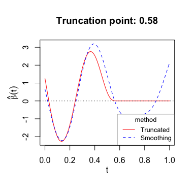

```r
plot(fit4)
```

### Predicting with fitted `FGLMtrunc` model for logistic regression

For functional logistic regression, each `type` option returns a different prediction:

- `type="link"` gives the linear predictors which are log-odds.
- `type="response"` gives the predicted probabilities.
- `type="coefficients"` gives truncated estimate of functional parameter $\beta$ as before.

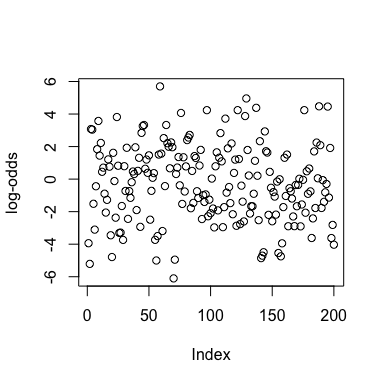

```r
logistic_link_pred = predict(fit4, newX.curves = Xcurves_logistic, type="link")
plot(logistic_link_pred, ylab="log-odds")
```

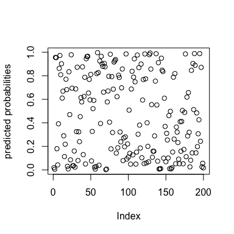

```r
logistic_response_pred = predict(fit4, newX.curves = Xcurves_logistic, type="response")
plot(logistic_response_pred, ylab="predicted probabilities")
```

## Functional Linear Regression with scalar predictors

### Fitting `FGLMtrunc` model

`FGLMtrunc` allows using scalar predictors together with functional predictors. First, we randomly generate observations for scalar predictors:

```r
scalar_coef <- c(1, -1, 0.5) # True coefficients for scalar predictors
set.seed(1234)
S <- cbind(matrix(rnorm(400), nrow=200), rbinom(200, 1, 0.5))  # Randomly generated observations for scalar predictors. Binary coded as 0 and 1.
colnames(S) <- c("s1", "s2", "s3")
```

Next, we modify the response vector from `LinearExample` so that it takes into account scalar predictors:

```r
Y_scalar <- Y_linear + (S %*% scalar_coef)
```

Then we fit `FGLMtrunc` model with the matrix of scalar predictors `S`:

```r
fit_scalar = fglm_trunc(X.curves=Xcurves_linear, Y=Y_scalar, S=S, nbasis = 50)
fit_scalar
```

```
#>
#> Call:  fglm_trunc(Y = Y_scalar, X.curves = Xcurves_linear, S = S, nbasis = 50)
#>
#>  Intercept      s1      s2     s3
#>     1.0865  1.0937 -1.0411 0.4233
#>
#> Optimal truncation point: 0.49
```

Fitted coefficients for scalar predictors are close to the true values.

### Predicting with scalar predictors

To make prediction with fitted model using scalar predictors, we need to specified argument `newS`:

```r
predict(fit_scalar, newX.curves = Xcurves_linear[1:5,], newS=S[1:5,])
```

```
#>            [,1]
#> [1,]  0.3837103
#> [2,]  1.2553910
#> [3,]  3.2764746
#> [4,] -3.4882131
#> [5,]  0.7946992
```